# Evaluation of basketball statistics

Blake Nelson, Nick Olech

2024-03-28

# Introduction

In this data science project, we dive into a data set containing NBA player statistics collected over more than 3 decades. This analysis not only offers a deeper understanding of player performance dynamics but also provides valuable insights for teams, analysts, and enthusiasts alike.

# Description of Data Set

For our project we are combining two different data sets. The first data frame has information for each player such as personal information and draft information like what position, draft year, and draft team. The second dataframe gives year by year information for each player in the first data frame. This information includes salary, season, and team.

### Ideas

- Look to determine what makes the perfect NBA “prospect”
- Utilize comparative analysis in order to predict future player success.
- By leveraging advanced analytically techniques, we aim to uncover insightful trends, patterns, and correlations within the data.

### Loading packages and data frames

```r
# Load required packages
library(ggplot2)
library(tidyverse)
library(dplyr)
library(scales)
```

```r
# Draft information Data Frame
df1 <-
  read.csv(
    "https://query.data.world/s/7fyub35dc6n4crgjosveptbc7uxeo3?dws=00000",
    header = TRUE,
    stringsAsFactors = FALSE
  )

# Salary information Data Frame
df2 <-
  read.csv(
    "https://query.data.world/s/6xhwdm7emdeglx4botceotj6udfevo?dws=00000",
    header = TRUE,
    stringsAsFactors = FALSE
  )
```

# First Data Cleaning Steps

```r
# Merge df1 (draft info) and df2 (salary statistics)
nba_stats <-
  merge(df2,
        df1,
        by.x = "player_id",
        by.y = "X_id",
        all.x = TRUE)

# Replaces empty values with NA
nba_stats <- nba_stats %>%
  mutate(across(where(is.character), ~ na_if(.x, "")))

# Convert data types
nba_stats <- nba_stats %>%
  mutate(
    height = as.numeric(sub("([0-9]+)-([0-9]+)", "\\1", height)) * 12 +
      as.numeric(sub("([0-9]+)-([0-9]+)", "\\2", height)),
    career_FG. = as.numeric(career_FG.),
    career_FT. = as.numeric(career_FT.),
    career_PER = as.numeric(career_PER),
    career_PTS = as.numeric(career_PTS),
    career_TRB = as.numeric(career_TRB),
    career_WS = as.numeric(career_WS),
    draft_pick = as.numeric(gsub("[^0-9]", "", draft_pick)),
    # Extract numeric values from draft pick
    weight = as.numeric(gsub("[^0-9.]", "", weight))           # Extract numeric values from weight
  )

# Drop missing values
nba_stats <- na.omit(nba_stats)

# Drop players that were drafted before 1980
nba_stats <- nba_stats %>%
  filter(draft_year >= 1980)
```

Note: Players that were drafted before 1980 are not accounted for in order to be more indicative of the modern era.

# Marginal Summaries

```r
str(nba_stats)
```

```
## 'data.frame':    10353 obs. of  30 variables:
##  $ player_id   : chr  "abdelal01" "abdelal01" "abdelal01" "abdelal01" ...
##  $ league      : chr  "NBA" "NBA" "NBA" "NBA" ...
##  $ salary      : int  395000 494000 500000 805000 650000 1660000 2008000 2358000 1825000 2200000 ...
##  $ season      : chr  "1990-91" "1991-92" "1992-93" "1993-94" ...
##  $ season_end  : int  1991 1992 1993 1994 1995 1991 1992 1993 1994 1995 ...
##  $ season_start: int  1990 1991 1992 1993 1994 1990 1991 1992 1993 1994 ...
##  $ team        : chr  "Portland Trail Blazers" "Portland Trail Blazers" "Boston Celtics" "Boston Celtics" ...
##  $ birthDate   : chr  "June 24, 1968" "June 24, 1968" "June 24, 1968" "June 24, 1968" ...
##  $ birthPlace  : chr  "Cairo, Egypt" "Cairo, Egypt" "Cairo, Egypt" "Cairo, Egypt" ...
##  $ career_AST  : num  0.3 0.3 0.3 0.3 0.3 3.5 3.5 3.5 3.5 3.5 ...
##  $ career_FG.  : num  50.2 50.2 50.2 50.2 50.2 44.2 44.2 44.2 44.2 44.2 ...
##  $ career_FG3. : chr  "0.0" "0.0" "0.0" "0.0" ...
##  $ career_FT.  : num  70.1 70.1 70.1 70.1 70.1 90.5 90.5 90.5 90.5 90.5 ...
##  $ career_G    : int  256 256 256 256 256 586 586 586 586 586 ...
```

[output cut: 18 more lines]

```r
head(nba_stats)
```

```
##   player_id league  salary  season season_end season_start
## 1 abdelal01    NBA  395000 1990-91       1991         1990
## 2 abdelal01    NBA  494000 1991-92       1992         1991
## 3 abdelal01    NBA  500000 1992-93       1993         1992
## 4 abdelal01    NBA  805000 1993-94       1994         1993
## 5 abdelal01    NBA  650000 1994-95       1995         1994
## 6 abdulma02    NBA 1660000 1990-91       1991         1990
##                     team     birthDate            birthPlace career_AST
## 1 Portland Trail Blazers June 24, 1968          Cairo, Egypt        0.3
## 2 Portland Trail Blazers June 24, 1968          Cairo, Egypt        0.3
## 3         Boston Celtics June 24, 1968          Cairo, Egypt        0.3
## 4         Boston Celtics June 24, 1968          Cairo, Egypt        0.3
## 5       Sacramento Kings June 24, 1968          Cairo, Egypt        0.3
## 6         Denver Nuggets March 9, 1969 Gulfport, Mississippi        3.5
##   career_FG. career_FG3. career_FT. career_G career_PER career_PTS career_TRB
```

[output cut: 27 more lines]

```r
summary(nba_stats)
```

```
##   player_id            league              salary            season
##  Length:10353       Length:10353       Min.   :    2706   Length:10353
##  Class :character   Class :character   1st Qu.:  745046   Class :character
##  Mode  :character   Mode  :character   Median : 1645200   Mode  :character
##                                        Mean   : 3274799
##                                        3rd Qu.: 4000000
##                                        Max.   :34682550
##    season_end    season_start      team            birthDate
##  Min.   :1985   Min.   :1984   Length:10353       Length:10353
##  1st Qu.:1996   1st Qu.:1995   Class :character   Class :character
##  Median :2003   Median :2002   Mode  :character   Mode  :character
##  Mean   :2003   Mean   :2002
##  3rd Qu.:2011   3rd Qu.:2010
##  Max.   :2018   Max.   :2017
##   birthPlace          career_AST       career_FG.    career_FG3.
##  Length:10353       Min.   : 0.000   Min.   : 0.00   Length:10353
##  Class :character   1st Qu.: 0.800   1st Qu.:42.50   Class :character
##  Mode  :character   Median : 1.600   Median :45.10   Mode  :character
##                     Mean   : 2.134   Mean   :45.36
##                     3rd Qu.: 2.900   3rd Qu.:48.30
##                     Max.   :10.500   Max.   :67.00
##    career_FT.        career_G        career_PER       career_PTS
##  Min.   :  0.00   Min.   :   1.0   Min.   :-18.40   Min.   : 0.000
##  1st Qu.: 69.10   1st Qu.: 375.0   1st Qu.: 11.80   1st Qu.: 5.700
##  Median : 75.10   Median : 633.0   Median : 13.80   Median : 8.700
##  Mean   : 73.74   Mean   : 627.9   Mean   : 13.95   Mean   : 9.564
##  3rd Qu.: 80.10   3rd Qu.: 867.0   3rd Qu.: 16.00   3rd Qu.:12.800
##  Max.   :100.00   Max.   :1504.0   Max.   : 27.90   Max.   :30.100
##    career_TRB       career_WS      career_eFG.          college
##  Min.   : 0.000   Min.   : -2.70   Length:10353       Length:10353
##  1st Qu.: 2.400   1st Qu.:  9.90   Class :character   Class :character
##  Median : 3.500   Median : 26.70   Mode  :character   Mode  :character
##  Mean   : 4.034   Mean   : 37.18
##  3rd Qu.: 5.100   3rd Qu.: 53.30
##  Max.   :13.700   Max.   :234.60
##    draft_pick     draft_round         draft_team         draft_year
##  Min.   :  1.00   Length:10353       Length:10353       Length:10353
##  1st Qu.:  8.00   Class :character   Class :character   Class :character
##  Median : 18.00   Mode  :character   Mode  :character   Mode  :character
##  Mean   : 22.21
##  3rd Qu.: 32.00
##  Max.   :221.00
##      height       highSchool            name             position
##  Min.   :63.00   Length:10353       Length:10353       Length:10353
##  1st Qu.:76.00   Class :character   Class :character   Class :character
##  Median :79.00   Mode  :character   Mode  :character   Mode  :character
##  Mean   :78.97
##  3rd Qu.:82.00
##  Max.   :91.00
##     shoots              weight
##  Length:10353       Min.   :133.0
##  Class :character   1st Qu.:195.0
##  Mode  :character   Median :218.0
##                     Mean   :217.5
##                     3rd Qu.:235.0
##                     Max.   :325.0
```

```r
dim(nba_stats)
```

```
## [1] 10353    30
```

# Questions to possibly research

## Does where you are born influence your likely hood of NBA success?

- Could look at salary or sheer number of NBA players from certain regions and then divide by each respective population.

First I want to look at the overall salaries that are listed in this dataset to get a sort of gague of what the numbers should look like.

```r
#Make so there are no repeat id's and get salary statistics
nba_salary_summary <- nba_stats %>%
  group_by(player_id) %>%
  summarize(
    Total_Salary = sum(salary, na.rm = TRUE),
    Average_Salary = mean(salary, na.rm = TRUE),
    .groups = 'drop'
  )
head(nba_salary_summary)
```

```
## # A tibble: 6 × 3
##   player_id Total_Salary Average_Salary
##   <chr>            <int>          <dbl>
## 1 abdelal01      2844000        568800
## 2 abdulma02     19849500       2205500
## 3 abdulta01     37982800       3798280
## 4 abdursh01     95866000       8715091.
## 5 ackeral01      1949488        649829.
## 6 acresma01      1609000        321800
```

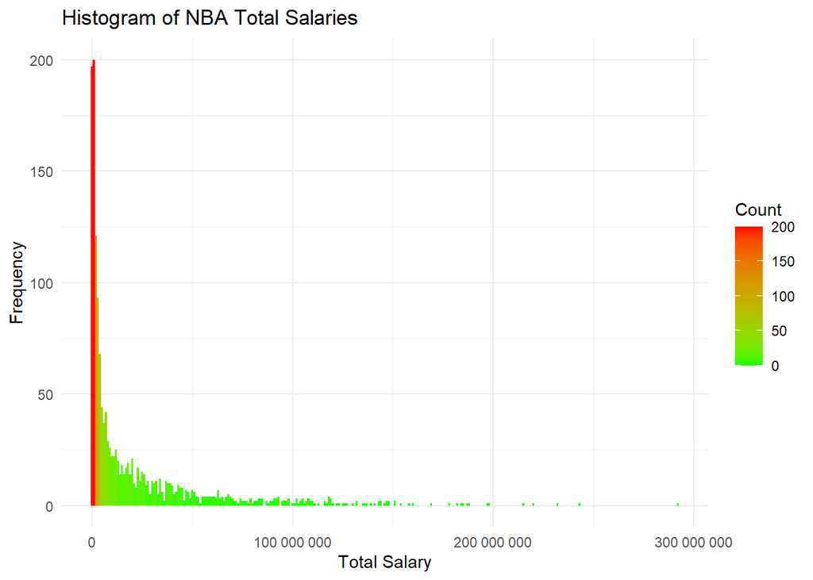

```r
#Plot the frequency of Total Salary
ggplot(data = nba_salary_summary, aes(x = Total_Salary, fill = ..count..)) +
  geom_histogram(binwidth = 1000000) +
  scale_fill_gradient("Count", low = "green", high = "red") +
  scale_x_continuous(labels = label_number()) +
  labs(title = "Histogram of NBA Total Salaries",
       x = "Total Salary",
       y = "Frequency") +
  theme_minimal()
```

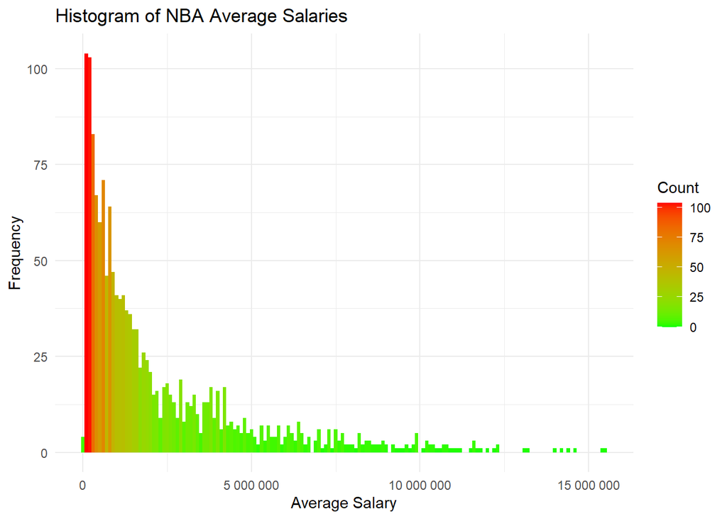

```r
#Plot the frequency of Average Salary
ggplot(data = nba_salary_summary, aes(x = Average_Salary, fill = ..count..)) +
  geom_histogram(binwidth = 100000) +
  scale_fill_gradient("Count", low = "green", high = "red") +
  scale_x_continuous(labels = label_number()) +
  labs(title = "Histogram of NBA Average Salaries",
       x = "Average Salary",
       y = "Frequency") +
  theme_minimal()
```

I am a little concerned that this dataset is not representative of how much players have made but since the data is pre 2019 this makes sense.

NBA salaries are increasingly inflated, especially in the last half decade, therefore it makes sense these numbers are lower than we are nowadays accustomed to.

```r
# Checking for average salaries greater than $15 million
high_salary_players <- nba_salary_summary %>%
  filter(Average_Salary > 15000000)

# Viewing the results
head(high_salary_players)
```

```
## # A tibble: 2 × 3
##   player_id Total_Salary Average_Salary
##   <chr>            <int>          <dbl>
## 1 anthoca01    232001415      15466761
## 2 onealsh01    292198327      15378859.
```

```r
count(high_salary_players)
```

```
## # A tibble: 1 × 1
##       n
##   <int>
## 1     2
```

Now lets look to answer “Does where you are born influence your likely hood of NBA success?”

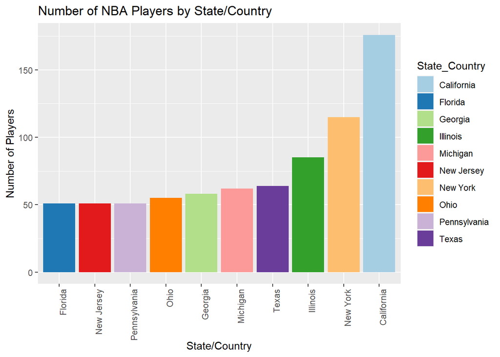

```r
#Separate the birthplace column into two separate rows and look at what city/state they are from
nba_birthplace_summary <- nba_stats %>%
  distinct(player_id, .keep_all = TRUE) %>%
  separate(
    birthPlace,
    into = c("City", "State_Country"),
    sep = ", ",
    extra = "merge"
  ) %>%
  group_by(player_id, State_Country) %>%
  ungroup() %>%
  count(State_Country, sort = TRUE)

#Plot which states/countries have the most players (top 10)
N <- 10

#Create variable that shows where most players are from (state/country)
top_nba_locations <- nba_birthplace_summary %>%
  top_n(N, n) %>%
  arrange(desc(n))

#Graph Findings
ggplot(top_nba_locations, aes(
  x = reorder(State_Country, n),
  y = n,
  fill = State_Country
)) +
  geom_bar(stat = "identity") +
  scale_fill_brewer(palette = "Paired") +
  labs(x = "State/Country", y = "Number of Players",
       title = "Number of NBA Players by State/Country") +
  theme(axis.text.x = element_text(angle = 90, hjust = 1))
```

```r
#Get a table that shows output
print(nba_birthplace_summary)
```

```
## # A tibble: 96 × 2
##    State_Country     n
##    <chr>         <int>
##  1 California      176
##  2 New York        115
##  3 Illinois         85
##  4 Texas            64
##  5 Michigan         62
##  6 Georgia          58
##  7 Ohio             55
##  8 Florida          51
##  9 New Jersey       51
## 10 Pennsylvania     51
## # ℹ 86 more rows
```

Population for each state/country - California 39.03 M - New York 19.68 M - Illinois 12.58 M - Texas 30.03 M - Georgia 10.91 M

```r
#Find players per state (One NBA player every x people)
Players_CA <- 39030000 / 184
Players_NY <- 19680000 / 117
Players_IL <- 12580000 / 92
Players_TX <- 30030000 / 68
Players_GA <- 10910000 / 65
```

```
## [1] "Players_CA =  212119.565217391"
```

```
## [1] "Players_NY =  168205.128205128"
```

```
## [1] "Players_IL =  136739.130434783"
```

```
## [1] "Players_TX =  441617.647058824"
```

```
## [1] "Players_GA =  167846.153846154"
```

```r
#Expressed as a percentage
Players_CAper <- 184 / 39030000
Players_NYper <- 117 / 19680000
Players_ILper <- 92 / 12580000
Players_TXper <- 68 / 30030000
Players_GAper <- 65 / 10910000
```

```
## [1] "Players_CAper =  4.71432231616705e-06"
```

```
## [1] "Players_NYper =  5.94512195121951e-06"
```

```
## [1] "Players_ILper =  7.31319554848967e-06"
```

```
## [1] "Players_TXper =  2.26440226440226e-06"
```

```
## [1] "Players_GAper =  5.95783684692942e-06"
```

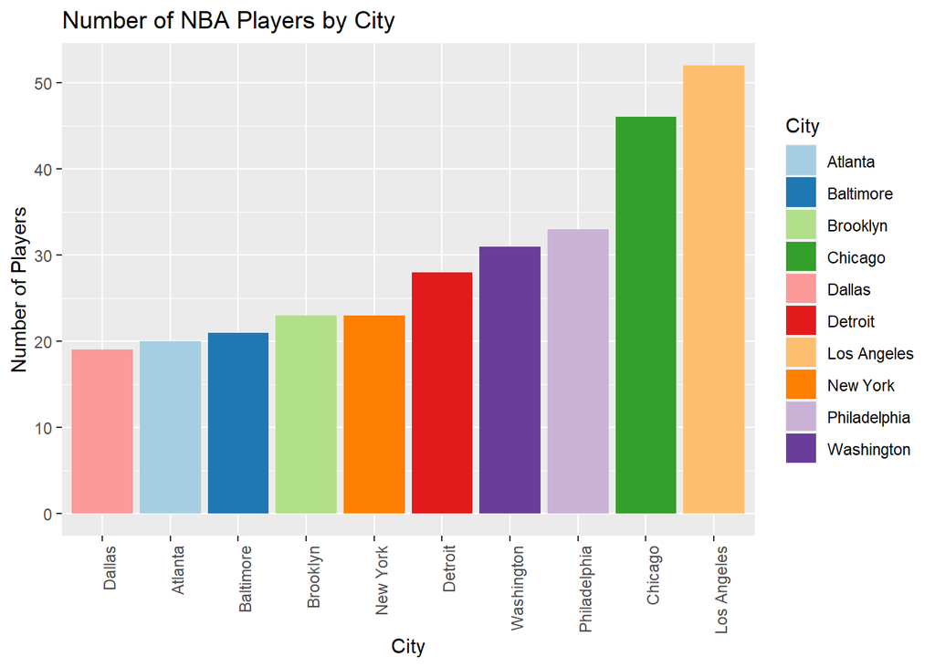

```r
#Same thing now, except group by city
nba_birthplace_city_summary <- nba_stats %>%
  distinct(player_id, .keep_all = TRUE) %>%
  separate(birthPlace, into = c("City", "State_Country"), sep = ", ", extra = "merge") %>%
  group_by(player_id, City) %>%
  ungroup() %>%
  count(City, sort = TRUE)

#Plot which cities have the most players (top 10)
top_nba_locations_cities <- nba_birthplace_city_summary %>%
  top_n(N, n) %>%
  arrange(desc(n))

#Plot findings
ggplot(top_nba_locations_cities, aes(x = reorder(City, n), y = n, fill = City)) +
  geom_bar(stat = "identity") +
  scale_fill_brewer(palette = "Paired") +  # Use a pre-defined color palette
  labs(x = "City", y = "Number of Players",
       title = "Number of NBA Players by City") +
  theme(axis.text.x = element_text(angle = 90, hjust = 1))
```

```r
#Print table
head(nba_birthplace_city_summary)
```

```
## # A tibble: 6 × 2
##   City             n
##   <chr>        <int>
## 1 Los Angeles     52
## 2 Chicago         46
## 3 Philadelphia    33
## 4 Washington      31
## 5 Detroit         28
## 6 Brooklyn        23
```

Populations for each city - Los Angeles: 3.822 M - Chicago 2.665 M - Philadelphia 1.567 M - Washington 671803 - Detroit 620376

```r
#Find players per state (One NBA player every x people)
Players_LA <- 3822000 / 54
Players_CHI <- 2665000 / 49
Players_PHIL <- 1567000 / 34
Players_WSH <- 671803 / 31
Players_DET <- 620376 / 28
```

[output not shown]

```
## [1] "Players_CHI =  54387.7551020408"
```

```
## [1] "Players_PHIL =  46088.2352941177"
```

```
## [1] "Players_WSH =  21671.064516129"
```

```
## [1] "Players_DET =  22156.2857142857"
```

```r
#Now express as a percentage
Players_LA_per <- 54 / 3822000
Players_CHI_per <- 49 / 2665000
Players_PHIL_per <- 34 / 1567000
Players_WSH_per <- 31 / 671803
Players_DET_per <- 28 / 620376
```

```
## [1] "Players_LA_per =  1.41287284144427e-05"
```

```
## [1] "Players_CHI_per =  1.83864915572233e-05"
```

```
## [1] "Players_PHIL_per =  2.16975111678366e-05"
```

```
## [1] "Players_WSH_per =  4.61444798549575e-05"
```

```
## [1] "Players_DET_per =  4.5133918784737e-05"
```

## What is the ideal height/weight (build) of an NBA Player?

- Could look at how salary relates to certain measurements a player has.

To find a correlation I looked at players that been in the NBA for more than 4 years.

```r
# Create a copy of nba_stats
ns_w_cd <- nba_stats

# Add career_duration column
ns_w_cd$career_duration <- ifelse(ns_w_cd$career_G > 4*82, "Over 4 Years", "Under 4 Years")

# Filter to include only unique player IDs
unique_players <- ns_w_cd %>%
  distinct(player_id, .keep_all = TRUE)
```

I then plotted the relationship between that duration and each players height and weight.

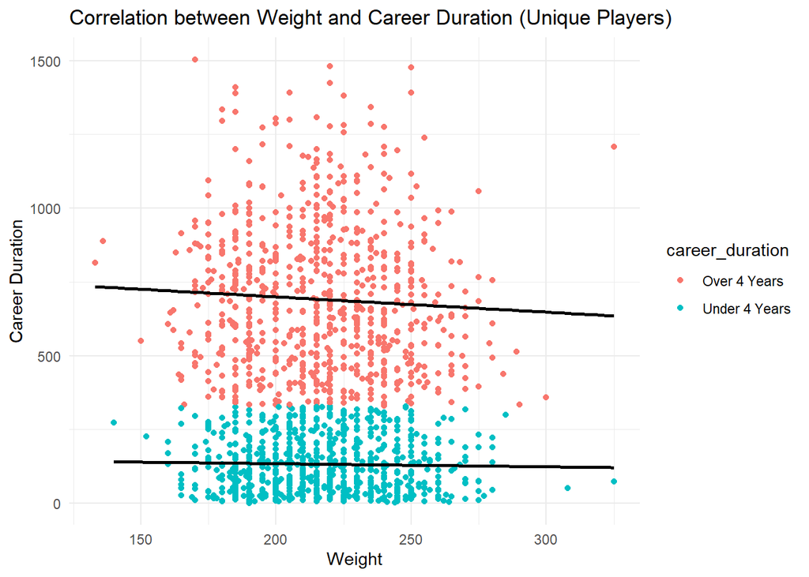

```r
# Plotting the correlation between weight and career duration
weight_duration_plot <- ggplot(unique_players, aes(x = weight, y = career_G, color = career_duration)) +
  geom_point() +
  geom_smooth(aes(group = career_duration), method = "lm", se = FALSE, color = "black") +  # Add black linear regression lines
  labs(title = "Correlation between Weight and Career Duration (Unique Players)", x = "Weight", y = "Career Duration") +
  theme_minimal()

# Display the plot
print(weight_duration_plot)
```

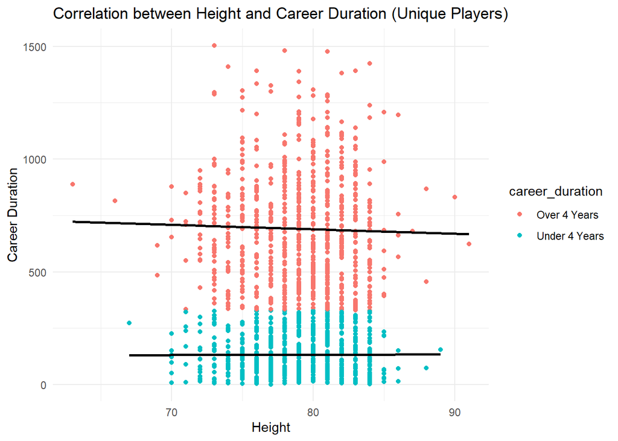

```r
# Plotting the correlation between height and career duration
height_duration_plot <- ggplot(unique_players, aes(x = height, y = career_G, color = career_duration)) +
  geom_point() +
  geom_smooth(aes(group = career_duration), method = "lm", se = FALSE, color = "black") +  # Add black linear regression lines
  labs(title = "Correlation between Height and Career Duration (Unique Players)", x = "Height", y = "Career Duration") +
  theme_minimal()

# Display the plot
print(height_duration_plot)
```

That gave some good information but I would also like to compare height and weight to salary. To do this I will make 2 side by side box plots.

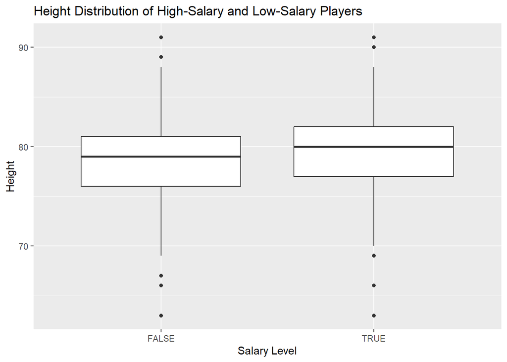

```r
# Boxplot of height for high-salary and low-salary players
ggplot(nba_stats, aes(x = factor(salary > median(salary)), y = height)) +
  geom_boxplot() +
  labs(title = "Height Distribution of High-Salary and Low-Salary Players",
       x = "Salary Level",
       y = "Height")
```

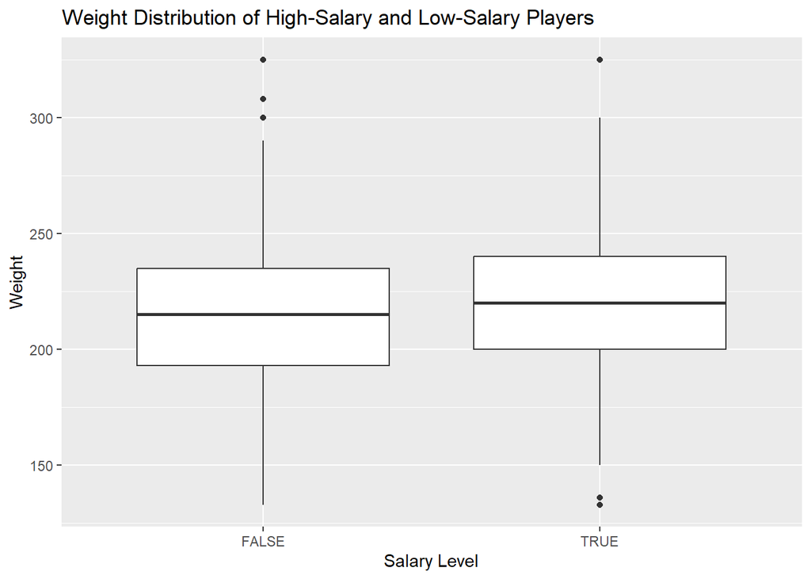

```r
# Boxplot of weight for high-salary and low-salary players
ggplot(nba_stats, aes(x = factor(salary > median(salary)), y = weight)) +
  geom_boxplot() +
  labs(title = "Weight Distribution of High-Salary and Low-Salary Players",
       x = "Salary Level",
       y = "Weight")
```

### short summary Weight and Height has an influence on success in the NBA, but not as much as we originally thought.

## What are the key performance indicators for success in basketball?

- Analyze salary VS win shares and some other potential key variables.

To find some key performance indicators, I plotted salary VS Efficiency Rating, Win shares, Draft Pick, and position.

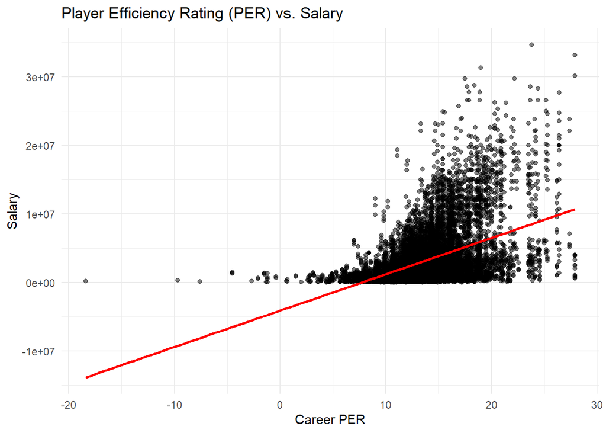

```r
#Player Efficiency Rating (PER) vs. Salary
ggplot(nba_stats, aes(x = career_PER, y = salary)) +
  geom_point(alpha = 0.5) +
  geom_smooth(method = "lm", se = FALSE, color = "red") +
  labs(title = "Player Efficiency Rating (PER) vs. Salary",
       x = "Career PER",
       y = "Salary") +
  theme_minimal()
```

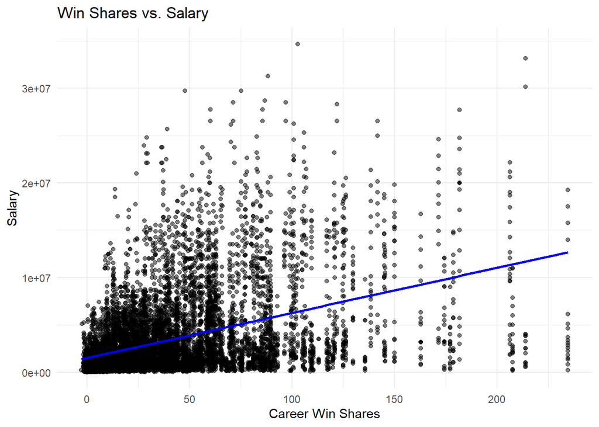

```r
#Win Shares vs. Salary
ggplot(nba_stats, aes(x = career_WS, y = salary)) +
  geom_point(alpha = 0.5) +
  geom_smooth(method = "lm", se = FALSE, color = "blue") +
  labs(title = "Win Shares vs. Salary",
       x = "Career Win Shares",
       y = "Salary") +
  theme_minimal()
```

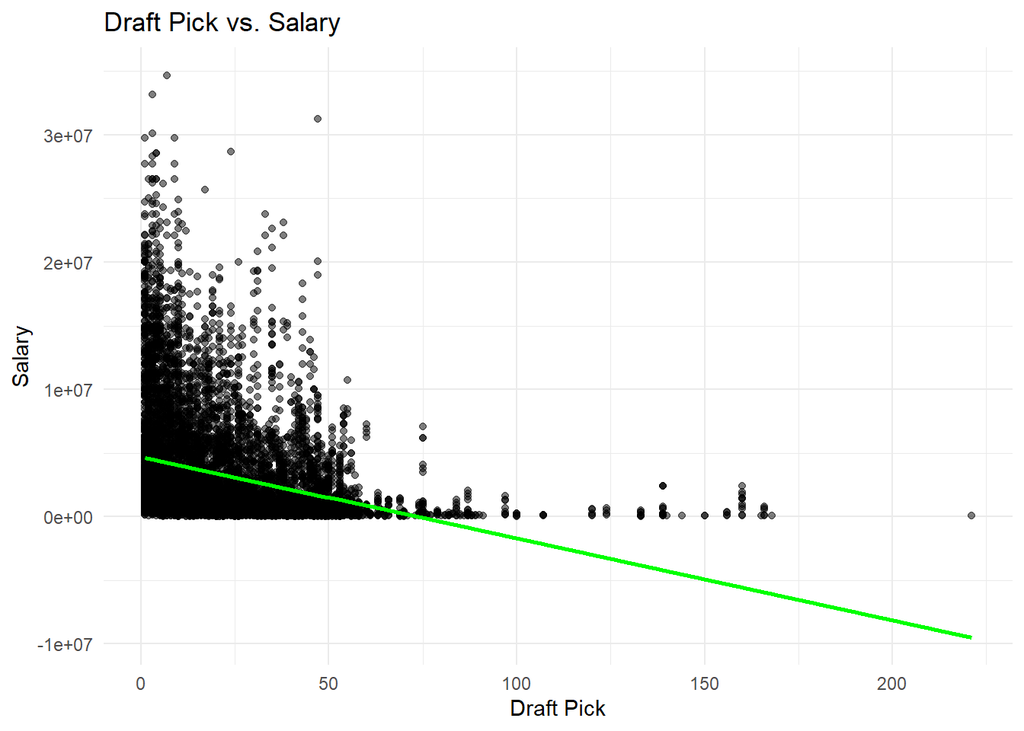

```r
#Draft Pick vs. Salary
ggplot(nba_stats, aes(x = draft_pick, y = salary)) +
  geom_point(alpha = 0.5) +
  geom_smooth(method = "lm", se = FALSE, color = "green") +
  labs(title = "Draft Pick vs. Salary",
       x = "Draft Pick",
       y = "Salary") +
  theme_minimal()
```

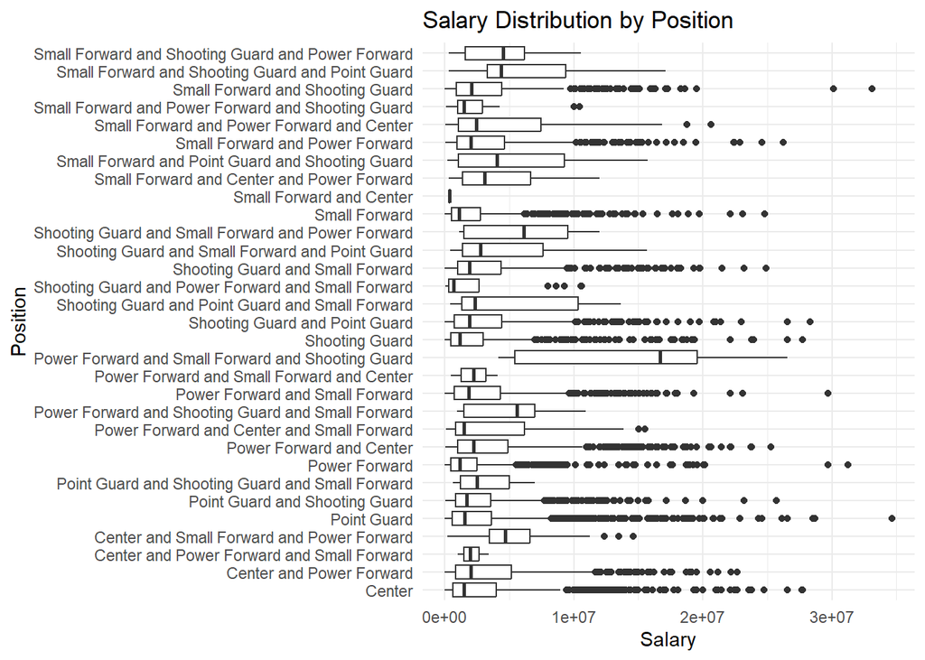

```r
# Create a scatter plot for Position vs. Salary
ggplot(nba_stats, aes(x = position, y = salary)) +
  geom_boxplot() +
  labs(title = "Salary Distribution by Position",
       x = "Position",
       y = "Salary") +
  theme_minimal() +
  coord_flip()
```

### Short Summary

Moderate correlation between win shares and salary, thus meaning that contributing to winning does not guarantee success but is linked to it.

## What position in basketball seems to contribute to winning the most?

- Could look to analyze win shares and other statistics relating to positions.

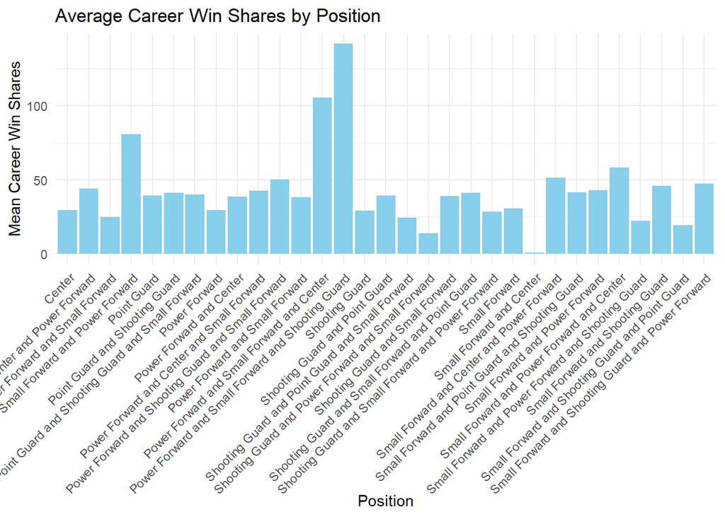

```r
# Aggregate data by position and calculate mean career win shares
position_summary <- nba_stats %>%
  group_by(position) %>%
  summarise(mean_career_WS = mean(career_WS, na.rm = TRUE))

# Create a bar plot
ggplot(position_summary, aes(x = position, y = mean_career_WS)) +
  geom_bar(stat = "identity", fill = "skyblue") +
  labs(
    title = "Average Career Win Shares by Position",
    x = "Position",
    y = "Mean Career Win Shares"
  ) +
  theme_minimal() +
  theme(axis.text.x = element_text(angle = 45, hjust = 1))
```

- Now look at it with just primary position

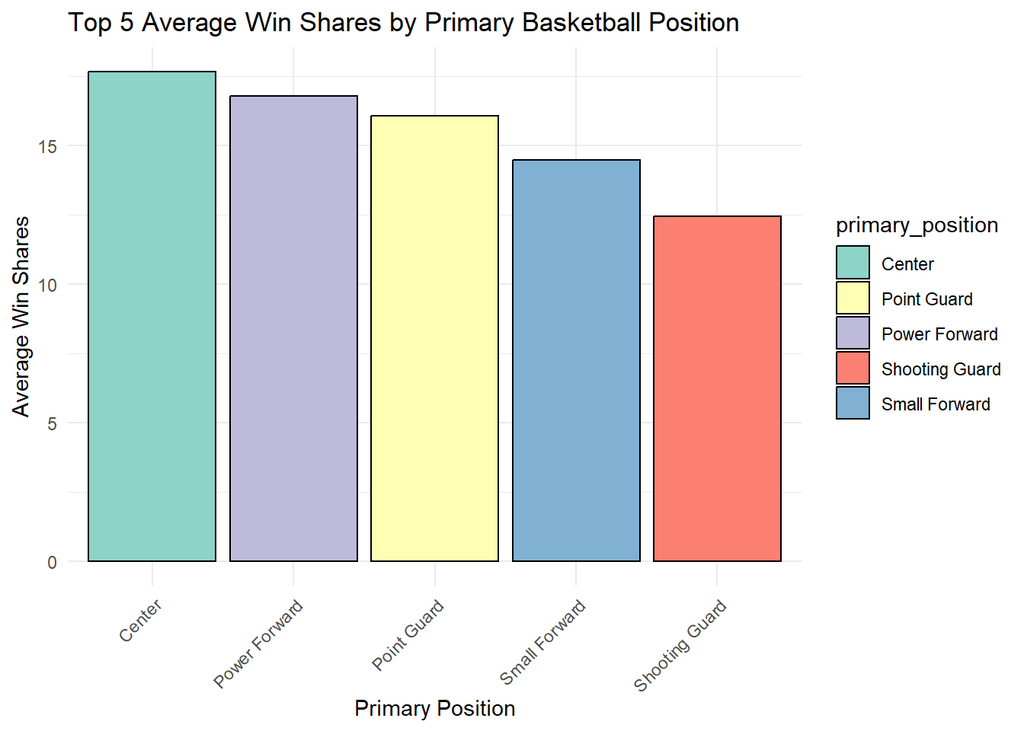

```r
#Make a new column that accounts for the primary position
df1$primary_position <- sapply(strsplit(df1$position, " and "), `[`, 1)

#Make sure that the number is numeric
df1$career_WS <- as.numeric(gsub("[^0-9\\.]", "", df1$career_WS))

#Group by primary_position and summarize average win shares
primary_position_summary <- df1 %>%
  group_by(primary_position) %>%
  summarise(average_win_shares = mean(career_WS, na.rm = TRUE)) %>%
  arrange(desc(average_win_shares))

#Just make sure that we only have the five basic positions
top_positions <- primary_position_summary %>%
  arrange(desc(average_win_shares)) %>%
  top_n(5, average_win_shares)

#Plotting using a bar chart
ggplot(top_positions, aes(x = reorder(primary_position, -average_win_shares), y = average_win_shares, fill = primary_position)) +
  geom_bar(stat = "identity", color = "black") +
  labs(x = "Primary Position", y = "Average Win Shares", title = "Top 5 Average Win Shares by Primary Basketball Position") +
  theme_minimal() +
  theme(axis.text.x = element_text(angle = 45, hjust = 1)) + # Rotate x-axis labels for better readability
  scale_fill_brewer(palette = "Set3")
```

### Short Summary

Primary position that the contributes the most to winning is center. Also, players with flexibility to play positions 2-4 were the most successful in NBA history.